# Citizen Attitudes towards Modern and Traditional Authority: Substitutes or Complements?

Authors: Peter van der Windt, Macartan Humphreys, Lily Medina, Jeffrey Timmons, and Maarten Voors

October 22, 2018

- [This .Rmd file](https://github.com/medinali/VDW-H-M-T-V/blob/master/Replication.Rmd) replicates all tables and figures reported in the manuscript [“*Citizen Attitudes towards Modern and Traditional Authority: Substitutes or Complements?*”](https://journals.sagepub.com/eprint/XiYVWJ8hAmTvFk6igcrg/full).
- Data comes from the local folder “data”. Helper functions are called up in the process from the local folder “code”. Figures are put into local folder “output”.
- [A pre-printed version of the paper](http://www.macartan.nyc/wp-content/uploads/2018/11/VDW-H-M-T-V_paper.pdf) can be found online.

#### Options

Indicate your preferences here. Fyi, the structural model (which can be turned on below) takes several hours to complete. The results from the fitted models can be found [here](https://www.dropbox.com/sh/1knr88h3m0zagc9/AABcxXXQEqN8RgIx7_1LaO1Ga?dl=0). You need to download these files to your local folder whenever `run_1re` or `run_2re` are set to FALSE.

```r
# Stan Setup
# 1re: model with random effects at chiefdom level
# 2re: model with random effects at chiefdom level and village level

seed <- 1
# Run structural model
run_1re <- FALSE
run_2re <- FALSE
# Simulate samples of the posterior predictive distribution
run_posteriors <- FALSE

outname_1re <- "stan_1re.Rdata"
outname_2re <- "stan_2re.Rdata"

options(mc.cores = parallel::detectCores())

chains <- 20
iters <- 4000
max_divergent <- 0 # Maximum divervent transitions accepted
```

#### Load Data and Helper Files

```r
# Load data from the local folder "data"
# The cleaning process and creation of shock variables has been kept out,
# as this required village-level GPS information, which cannot be made public.
hh <- read.csv(file = "data/hh.csv")
vill_data <- read.csv(file = "data/vill_data.csv")
shocks <- read.csv(file = "data/shocks.csv")

# Load additional helper functions
source("code/1_helper_functions.R")
```

# Table 1: Measures Related to the Modern Contract

```r
G1 <-  c( "q078_a_elections" ,
          "q078_b_complaints" ,
          "q078_c_suggestions" ,
          "q078_corruption" ,
          "q078_d_sensibiliser",
          "q078_f_consult",
          "q078_g_pork")
G2  <-  c("q077_a_vote",
          "q077_b_complain",
          "q077_c_suggest",
          "q077_d_meetings",
          "q077_e_obey",
          "q077_f_taxes",
          "q077_g_support")
G3  <-  c("q076_edu_e",
          "q076_sante_e")
G4  <-  c("q079_f_police",
          "q079_g_state")
C1  <-  c("qd2_chief" ,
          "qd6_chief" ,
          "qd7_chief" )

summ <- function(var, my_data = hh) cbind( sum(!is.na(my_data[,`var`])),
                                  round(mean(my_data[,`var`],na.rm = TRUE),3),
                                  round(sd(my_data[,`var`],  na.rm = TRUE), 3),
                                  min(my_data[,`var`], na.rm = TRUE),
                                  max(my_data[,`var`], na.rm = TRUE))

gvars <- data.frame(family = c("Responsibilities of the state", rep("",length(G1)),
                                "Responsibilities of citizens", rep("",length(G2)),
                                "Value of state activities",    rep("",length(G3)),
                                "Citizen activities",           rep("",length(G4)),
                                "Overall mean modern contract"),


                       dep_var = c("Accept elections results",
                                    "React to complaints",
                                    "React to suggestions",
                                    "Avoid corruption",
                                    "Keep people informed",
                                    "Consult population",
                                    "Contribute resources",
                                    "---Family Mean---",
                                    "Vote",
                                    "Complain" ,
                                    "Make suggestions",
                                    "Attend meetings",
                                    "Obey the law",
                                    "Pay Tax",
                                    "Support government",
                                    "---Family Mean---",
                                    "Providing education",
                                    "Providing health care",
                                    "---Family Mean---",
                                    "Contact police",
                                    " Visit to government agency",
                                   "---Family Mean---",
                                   "")
                                    )

 gsumm <- cbind(gvars, t(sapply(c(G1, "G1", G2, "G2", G3, "G3", G4, "G4", "G"), summ)))

 kable( gsumm, row.names = FALSE, col.names = c("Family", "Dependent Variable", "Obs", "Mean", "St. Dev", "Min", "Max"), digits = 3)
```

| Family | Dependent Variable | Obs | Mean | St. Dev | Min | Max |
| --- | --- | --- | --- | --- | --- | --- |
| Responsibilities of the state | Accept elections results | 3734 | 0.239 | 0.427 | 0 | 1 |
|  | React to complaints | 3734 | 0.521 | 0.500 | 0 | 1 |
|  | React to suggestions | 3734 | 0.446 | 0.497 | 0 | 1 |
|  | Avoid corruption | 3734 | 0.302 | 0.459 | 0 | 1 |
|  | Keep people informed | 3734 | 0.273 | 0.446 | 0 | 1 |
|  | Consult population | 3734 | 0.310 | 0.463 | 0 | 1 |
|  | Contribute resources | 3734 | 0.562 | 0.496 | 0 | 1 |
|  | —Family Mean— | 3734 | 0.379 | 0.319 | 0 | 1 |
| Responsibilities of citizens | Vote | 3733 | 0.334 | 0.472 | 0 | 1 |
|  | Complain | 3733 | 0.287 | 0.452 | 0 | 1 |
|  | Make suggestions | 3733 | 0.216 | 0.412 | 0 | 1 |
|  | Attend meetings | 3733 | 0.246 | 0.431 | 0 | 1 |
|  | Obey the law | 3733 | 0.597 | 0.490 | 0 | 1 |
|  | Pay Tax | 3733 | 0.459 | 0.498 | 0 | 1 |
|  | Support government | 3733 | 0.203 | 0.402 | 0 | 1 |
|  | —Family Mean— | 3733 | 0.335 | 0.300 | 0 | 1 |
| Value of state activities | Providing education | 3699 | 0.151 | 0.358 | 0 | 1 |
|  | Providing health care | 3686 | 0.133 | 0.339 | 0 | 1 |
|  | —Family Mean— | 3736 | 0.143 | 0.307 | 0 | 1 |
| Citizen activities | Contact police | 3721 | 0.033 | 0.178 | 0 | 1 |
|  | Visit to government agency | 3733 | 0.032 | 0.176 | 0 | 1 |
|  | —Family Mean— | 3734 | 0.033 | 0.152 | 0 | 1 |
| Overall mean modern contract |  | 3758 | 0.222 | 0.180 | 0 | 1 |

# Table 2: Measures Related to the Traditional Contract

```r
cvars <- data.frame(family = c("Desired role of chief as development broker ",rep("",length(C1))),
                       dep_var = c("Beneficiary choice",
                                    "Fund allocation",
                                    "Project supervision",
                                    "---Family Mean---"))

csumm <- cbind(cvars, t(sapply(c(C1, "C1"), summ)))

kable(csumm , row.names = FALSE, col.names = c("Family", "Dependent Variable", "Obs", "Mean", "St. Dev", "Min", "Max"))
```

| Family | Dependent Variable | Obs | Mean | St. Dev | Min | Max |
| --- | --- | --- | --- | --- | --- | --- |
| Desired role of chief as development broker | Beneficiary choice | 3853 | 0.517 | 0.500 | 0 | 1 |
|  | Fund allocation | 3853 | 0.422 | 0.494 | 0 | 1 |
|  | Project supervision | 3853 | 0.380 | 0.485 | 0 | 1 |
|  | —Family Mean— | 3853 | 0.439 | 0.383 | 0 | 1 |

# Table 3: Measures Related to the Shocks

```r
summ2 <- function(x) c(length(x), mean(x), sd(x), min(x), max(x))

shocks_summ <- sapply(list(shocks$avg_rain_dev, shocks$Confl_Shock), summ2) %>% t()

rownames(shocks_summ) <- c("Rainfall Shock", "Conflict Shock")

kable(shocks_summ , col.names =  c( "Obs.", "Mean", "St. Dev."," Min" ,"Max") , digits = 3 )
```

|  | Obs. | Mean | St. Dev. | Min | Max |
| --- | --- | --- | --- | --- | --- |
| Rainfall Shock | 1020 | 3.550 | 1.898 | 0.98 | 8.267 |
| Conflict Shock | 1020 | -0.028 | 0.328 | -2.50 | 2.250 |

# Table 4. Correlation between Modern and Traditional Contracts

```r
y <- c("G1", "G2" ,"G3", "G4", "G")

stargazer.lmrobust <- function(lmrobust_object, fe = "Y"){
 rows <- 10
 output <- rep("",rows)
 pvalues <- lmrobust_object$p.value[c("C1", "age", "age2", "lit", "male")]
 stars   <- ifelse(pvalues < 0.01 ,"***",
                   ifelse(pvalues < 0.05 & pvalues>=0.01, "**",
                          ifelse(pvalues < 0.1 & pvalues>=0.05, "*", "")))

  output[1:rows%%2!=0] <- paste0(round(lmrobust_object$coefficients[c("C1", "age", "age2", "lit", "male")],3), stars)
  output[1:rows%%2==0] <- paste0("(", round(lmrobust_object$std.error[2:5],3), ")") # names are not recognized..need to use index

 output <- c( output, fe, lmrobust_object$N, round(lmrobust_object$r.squared , 3))

}


## regressions without fixed effects
no_fe <- lapply(y, function(y)
  estimatr::lm_robust(formula = as.formula(paste0(y, "~ C1 + age + age2 + lit + male")), data = hh ))

## regressions with fixed effects
fe <- lapply(y, function(y)
  estimatr::lm_robust(formula = as.formula(paste0(y, "~ C1 + age + age2+lit + male + as.factor(IDS_CHEF)")), data = hh ))

## Create Correlations table
corrs <- cbind (sapply(no_fe, stargazer.lmrobust, fe = "N"), sapply(fe, stargazer.lmrobust))
rownames(corrs) <- c("Desired role of chief", "", "Age", "","Age2", "","Literate", "","Male","", "FE", "N", "R2")

kable(corrs, col.names = rep(c("Resp. State" , "Resp. citizen"  , "Valuation State", "Citizen Activities","Index" ),2))
```

|  | Resp. State | Resp. citizen | Valuation State | Citizen Activities | Index | Resp. State | Resp. citizen | Valuation State | Citizen Activities | Index |
| --- | --- | --- | --- | --- | --- | --- | --- | --- | --- | --- |
| Desired role of chief | -0.104*** | -0.067*** | -0.053*** | -0.015** | -0.06*** | -0.076*** | -0.055*** | -0.037*** | -0.008 | -0.045*** |
|  | (0.013) | (0.012) | (0.013) | (0.006) | (0.007) | (0.013) | (0.012) | (0.013) | (0.006) | (0.007) |
| Age | 0.013 | 0.034* | 0.015 | 0.018** | 0.019* | 0.035* | 0.04** | 0.03* | 0.027*** | 0.032*** |
|  | (0.019) | (0.018) | (0.017) | (0.008) | (0.01) | (0.019) | (0.018) | (0.017) | (0.008) | (0.01) |
| Age2 | -0.001 | -0.003* | -0.002 | -0.002* | -0.002 | -0.003 | -0.004* | -0.003* | -0.003*** | -0.003*** |
|  | (0.002) | (0.002) | (0.002) | (0.001) | (0.001) | (0.002) | (0.002) | (0.002) | (0.001) | (0.001) |
| Literate | 0.029** | 0.028** | 0.026** | 0.014*** | 0.027*** | 0.026** | 0.027** | 0.024** | 0.015*** | 0.025*** |
|  | (0.012) | (0.011) | (0.011) | (0.005) | (0.006) | (0.012) | (0.011) | (0.011) | (0.005) | (0.006) |
| Male | 0.04*** | 0.056*** | -0.006 | 0.016*** | 0.027*** | 0.045*** | 0.057*** | -0.005 | 0.016*** | 0.028*** |
|  | (0.013) | (0.012) | (0.013) | (0.006) | (0.007) | (0.013) | (0.012) | (0.013) | (0.006) | (0.007) |
| FE | N | N | N | N | N | Y | Y | Y | Y | Y |
| N | 3508 | 3507 | 3509 | 3507 | 3528 | 3508 | 3507 | 3509 | 3507 | 3528 |
| R2 | 0.029 | 0.027 | 0.007 | 0.012 | 0.039 | 0.078 | 0.062 | 0.053 | 0.044 | 0.087 |

# Table A3-A14. Relationship Modern and Traditional Contracts (individual level)

Script to produce tables for relationship modern and traditional contracts using individual level measures. These analyses make use of chiefdom fixed effects.

## Results for Responsibilities of the State

```r
Names <- c("Accept elections results" , "React to complaints"  , "React to suggestions", "Avoid corruption","Keep people informed", "Consult population", "Contribute resources" )

# Chief: Beneficiary Choice (QD2)
fe <- lapply(y_G1, function(y)
  estimatr::lm_robust(formula = as.formula(paste0(y, "~ qd2_chief + age + age2+lit + male + as.factor(IDS_CHEF)")), data = hh ))
corrs <- sapply(fe, stargazer.lmrobust_qd2, fe = "Y")
rownames(corrs) <- c("Chief: Beneficiary Choice", "", "Age", "","Age2", "","Literate", "","Male","", "FE", "N", "R2")
corrs<-corrs[c(1:2,11:13),]
kable(corrs, col.names = Names)
```

|  | Accept elections results | React to complaints | React to suggestions | Avoid corruption | Keep people informed | Consult population | Contribute resources |
| --- | --- | --- | --- | --- | --- | --- | --- |
| Chief: Beneficiary Choice | -0.02* | -0.03** | -0.05*** | -0.08*** | -0.03* | -0.04** | 0 |
|  | (0.01) | (0.02) | (0.02) | (0.02) | (0.01) | (0.02) | (0.02) |
| FE | Y | Y | Y | Y | Y | Y | Y |
| N | 3508 | 3508 | 3508 | 3508 | 3508 | 3508 | 3508 |
| R2 | 0.05 | 0.06 | 0.08 | 0.05 | 0.05 | 0.04 | 0.05 |

```r
# Chief: Fund Allocation (QD6)
fe <- lapply(y_G1, function(y)
  estimatr::lm_robust(formula = as.formula(paste0(y, "~ qd6_chief + age + age2+lit + male + as.factor(IDS_CHEF)")), data = hh ))
corrs <- sapply(fe, stargazer.lmrobust_qd6, fe = "Y")
rownames(corrs) <- c("Chief: Fund Allocation", "", "Age", "","Age2", "","Literate", "","Male","", "FE", "N", "R2")
corrs<-corrs[c(1:2,11:13),]
kable(corrs, col.names = Names)
```

|  | Accept elections results | React to complaints | React to suggestions | Avoid corruption | Keep people informed | Consult population | Contribute resources |
| --- | --- | --- | --- | --- | --- | --- | --- |
| Chief: Fund Allocation | -0.05*** | -0.08*** | -0.07*** | -0.1*** | -0.06*** | -0.05*** | 0 |
|  | (0.01) | (0.02) | (0.02) | (0.02) | (0.01) | (0.02) | (0.02) |
| FE | Y | Y | Y | Y | Y | Y | Y |
| N | 3508 | 3508 | 3508 | 3508 | 3508 | 3508 | 3508 |
| R2 | 0.06 | 0.06 | 0.08 | 0.06 | 0.05 | 0.04 | 0.05 |

```r
# Chief: Project Supervision (QD7)
fe <- lapply(y_G1, function(y)
  estimatr::lm_robust(formula = as.formula(paste0(y, "~ qd7_chief + age + age2+lit + male + as.factor(IDS_CHEF)")), data = hh ))
corrs <- sapply(fe, stargazer.lmrobust_qd7, fe = "Y")
rownames(corrs) <- c("Chief: Project Supervision", "", "Age", "","Age2", "","Literate", "","Male","", "FE", "N", "R2")
corrs<-corrs[c(1:2,11:13),]
kable(corrs, col.names = Names)
```

|  | Accept elections results | React to complaints | React to suggestions | Avoid corruption | Keep people informed | Consult population | Contribute resources |
| --- | --- | --- | --- | --- | --- | --- | --- |
| Chief: Project Supervision | -0.04** | -0.05*** | -0.07*** | -0.08*** | -0.07*** | 0 | 0 |
|  | (0.01) | (0.02) | (0.02) | (0.02) | (0.02) | (0.02) | (0.02) |
| FE | Y | Y | Y | Y | Y | Y | Y |
| N | 3508 | 3508 | 3508 | 3508 | 3508 | 3508 | 3508 |
| R2 | 0.05 | 0.06 | 0.08 | 0.05 | 0.05 | 0.04 | 0.05 |

## Results for Responsibilities of Citizens

```r
Names <- c("Vote","Complain", "Make suggestions","Attend meetings", "Obey the law","Pay tax", "Support government")

# Chief: Beneficiary Choice (QD2)
fe <- lapply(y_G2, function(y)
  estimatr::lm_robust(formula = as.formula(paste0(y, "~ qd2_chief + age + age2+lit + male + as.factor(IDS_CHEF)")), data = hh ))
corrs <- sapply(fe, stargazer.lmrobust_qd2, fe = "Y")
rownames(corrs) <- c("Chief: Beneficiary Choice", "", "Age", "","Age2", "","Literate", "","Male","", "FE", "N", "R2")
corrs<-corrs[c(1:2,11:13),]
kable(corrs, col.names = Names)
```

|  | Vote | Complain | Make suggestions | Attend meetings | Obey the law | Pay tax | Support government |
| --- | --- | --- | --- | --- | --- | --- | --- |
| Chief: Beneficiary Choice | -0.05*** | -0.02 | -0.04*** | -0.04*** | 0 | -0.01 | -0.02 |
|  | (0.02) | (0.02) | (0.01) | (0.01) | (0.02) | (0.02) | (0.01) |
| FE | Y | Y | Y | Y | Y | Y | Y |
| N | 3507 | 3507 | 3507 | 3507 | 3507 | 3507 | 3507 |
| R2 | 0.05 | 0.03 | 0.03 | 0.04 | 0.06 | 0.05 | 0.04 |

```r
# Chief: Fund Allocation (QD6)
fe <- lapply(y_G2, function(y)
  estimatr::lm_robust(formula = as.formula(paste0(y, "~ qd6_chief + age + age2+lit + male + as.factor(IDS_CHEF)")), data = hh ))
corrs <- sapply(fe, stargazer.lmrobust_qd6, fe = "Y")
rownames(corrs) <- c("Chief: Fund Allocation", "", "Age", "","Age2", "","Literate", "","Male","", "FE", "N", "R2")
corrs<-corrs[c(1:2,11:13),]
kable(corrs, col.names = Names)
```

|  | Vote | Complain | Make suggestions | Attend meetings | Obey the law | Pay tax | Support government |
| --- | --- | --- | --- | --- | --- | --- | --- |
| Chief: Fund Allocation | -0.07*** | -0.06*** | -0.05*** | -0.05*** | -0.02 | -0.01 | 0 |
|  | (0.02) | (0.02) | (0.01) | (0.01) | (0.02) | (0.02) | (0.01) |
| FE | Y | Y | Y | Y | Y | Y | Y |
| N | 3507 | 3507 | 3507 | 3507 | 3507 | 3507 | 3507 |
| R2 | 0.05 | 0.03 | 0.03 | 0.04 | 0.06 | 0.05 | 0.04 |

```r
# Chief: Project Supervision (QD7)
fe <- lapply(y_G2, function(y)
  estimatr::lm_robust(formula = as.formula(paste0(y, "~ qd7_chief + age + age2+lit + male + as.factor(IDS_CHEF)")), data = hh ))
corrs <- sapply(fe, stargazer.lmrobust_qd7, fe = "Y")
rownames(corrs) <- c("Chief: Project Supervision", "", "Age", "","Age2", "","Literate", "","Male","", "FE", "N", "R2")
corrs<-corrs[c(1:2,11:13),]
kable(corrs, col.names = Names)
```

|  | Vote | Complain | Make suggestions | Attend meetings | Obey the law | Pay tax | Support government |
| --- | --- | --- | --- | --- | --- | --- | --- |
| Chief: Project Supervision | -0.06*** | -0.04** | -0.04*** | -0.04*** | -0.04** | -0.03** | 0 |
|  | (0.02) | (0.02) | (0.01) | (0.01) | (0.02) | (0.02) | (0.01) |
| FE | Y | Y | Y | Y | Y | Y | Y |
| N | 3507 | 3507 | 3507 | 3507 | 3507 | 3507 | 3507 |
| R2 | 0.05 | 0.03 | 0.03 | 0.04 | 0.06 | 0.05 | 0.04 |

## Results for Valuation of the State

```r
Names <- c("Providing education" , "Providing health care")

# Chief: Beneficiary Choice (QD2)
fe <- lapply(y_G3, function(y)
  estimatr::lm_robust(formula = as.formula(paste0(y, "~ qd2_chief + age + age2+lit + male + as.factor(IDS_CHEF)")), data = hh ))
corrs <- sapply(fe, stargazer.lmrobust_qd2, fe = "Y")
rownames(corrs) <- c("Chief: Beneficiary Choice", "", "Age", "","Age2", "","Literate", "","Male","", "FE", "N", "R2")
corrs<-corrs[c(1:2,11:13),]
kable(corrs, col.names = Names)
```

|  | Providing education | Providing health care |
| --- | --- | --- |
| Chief: Beneficiary Choice | -0.02 | -0.03** |
|  | (0.01) | (0.01) |
| FE | Y | Y |
| N | 3477 | 3465 |
| R2 | 0.05 | 0.04 |

```r
# Chief: Fund Allocation (QD6)
fe <- lapply(y_G3, function(y)
  estimatr::lm_robust(formula = as.formula(paste0(y, "~ qd6_chief + age + age2+lit + male + as.factor(IDS_CHEF)")), data = hh ))
corrs <- sapply(fe, stargazer.lmrobust_qd6, fe = "Y")
rownames(corrs) <- c("Chief: Fund Allocation", "", "Age", "","Age2", "","Literate", "","Male","", "FE", "N", "R2")
corrs<-corrs[c(1:2,11:13),]
kable(corrs, col.names = Names)
```

|  | Providing education | Providing health care |
| --- | --- | --- |
| Chief: Fund Allocation | -0.01 | -0.01 |
|  | (0.01) | (0.01) |
| FE | Y | Y |
| N | 3477 | 3465 |
| R2 | 0.05 | 0.04 |

```r
# Chief: Project Supervision (QD7)
fe <- lapply(y_G3, function(y)
  estimatr::lm_robust(formula = as.formula(paste0(y, "~ qd7_chief + age + age2+lit + male + as.factor(IDS_CHEF)")), data = hh ))
corrs <- sapply(fe, stargazer.lmrobust_qd7, fe = "Y")
rownames(corrs) <- c("Chief: Project Supervision", "", "Age", "","Age2", "","Literate", "","Male","", "FE", "N", "R2")
corrs<-corrs[c(1:2,11:13),]
kable(corrs, col.names = Names)
```

|  | Providing education | Providing health care |
| --- | --- | --- |
| Chief: Project Supervision | -0.04*** | -0.02* |
|  | (0.01) | (0.01) |
| FE | Y | Y |
| N | 3477 | 3465 |
| R2 | 0.05 | 0.04 |

## Results for Citizen Activities

```r
Names <- c("Contact police" , "Visit to government agency")

# Chief: Beneficiary Choice (QD2)
fe <- lapply(y_G4, function(y)
  estimatr::lm_robust(formula = as.formula(paste0(y, "~ qd2_chief + age + age2+lit + male + as.factor(IDS_CHEF)")), data = hh ))
corrs <- sapply(fe, stargazer.lmrobust_qd2, fe = "Y")
rownames(corrs) <- c("Chief: Beneficiary Choice", "", "Age", "","Age2", "","Literate", "","Male","", "FE", "N", "R2")
corrs<-corrs[c(1:2,11:13),]
kable(corrs, col.names = Names)
```

|  | Contact police | Visit to government agency |
| --- | --- | --- |
| Chief: Beneficiary Choice | 0 | -0.01 |
|  | (0.01) | (0.01) |
| FE | Y | Y |
| N | 3495 | 3506 |
| R2 | 0.04 | 0.03 |

```r
# Chief: Fund Allocation (QD6)
fe <- lapply(y_G4, function(y)
  estimatr::lm_robust(formula = as.formula(paste0(y, "~ qd6_chief + age + age2+lit + male + as.factor(IDS_CHEF)")), data = hh ))
corrs <- sapply(fe, stargazer.lmrobust_qd6, fe = "Y")
rownames(corrs) <- c("Chief: Fund Allocation", "", "Age", "","Age2", "","Literate", "","Male","", "FE", "N", "R2")
corrs<-corrs[c(1:2,11:13),]
kable(corrs, col.names = Names)
```

|  | Contact police | Visit to government agency |
| --- | --- | --- |
| Chief: Fund Allocation | 0 | -0.01 |
|  | (0.01) | (0.01) |
| FE | Y | Y |
| N | 3495 | 3506 |
| R2 | 0.04 | 0.03 |

```r
# Chief: Project Supervision (QD7)
fe <- lapply(y_G4, function(y)
  estimatr::lm_robust(formula = as.formula(paste0(y, "~ qd7_chief + age + age2+lit + male + as.factor(IDS_CHEF)")), data = hh ))
corrs <- sapply(fe, stargazer.lmrobust_qd7, fe = "Y")
rownames(corrs) <- c("Chief: Project Supervision", "", "Age", "","Age2", "","Literate", "","Male","", "FE", "N", "R2")
corrs<-corrs[c(1:2,11:13),]
kable(corrs, col.names = Names)
```

|  | Contact police | Visit to government agency |
| --- | --- | --- |
| Chief: Project Supervision | 0 | -0.01 |
|  | (0.01) | (0.01) |
| FE | Y | Y |
| N | 3495 | 3506 |
| R2 | 0.04 | 0.03 |

# Table 5. Structural Model Parameter Estimates

The table below presents the results from estimating equations (4) and (5) in the manuscript. First, data is prepared:

```r
#write.csv(hh, file = "data_temp/hh.csv")
stan_hh <- dplyr::filter(hh, complete.cases(IDS_CHEF, IDV, rain, confl, C1, G ))

d    <- length(unique(stan_hh$IDS_CHEF))
k    <- length(unique(stan_hh$IDV))


stan_hh  %<>% mutate(chiefdom = as.numeric(factor(IDS_CHEF, labels = 1:d)),
                      village  = as.numeric(factor(IDV, labels = 1:k) ))

idv_chef <- dplyr::group_by( stan_hh,  village, chiefdom )%>%
             dplyr::summarise(n())


x      <- dplyr::select(stan_hh, C1,  G)

n      <- nrow(x)

sdata  <- list(n = n,
               k = k,
               d = d,
               x = x ,
               rain  = stan_hh$rain,
               confl = stan_hh$confl,
               chiefdom = stan_hh$chiefdom ,
               idv = stan_hh$village) # to be passed on to Stan
```

Next, run Stan model with random effects at the chiefdom level:

```r
## Random effects at chiefdom level

model_1re <- "
// Pearson Correlation
data {
int<lower=0> n;
int<lower=0> k;
int<lower=0> d;
vector[2] x[n];
vector[n] rain;
vector[n] confl;
int chiefdom[n];
int idv[n];


}
parameters {
real<lower=0.1>        CES;
vector<lower=0.001>[2]     sigma;
real<lower=-.999,upper=.999> r;
real  a_g;
real  b_g;
real  g_g;
real  a_c;
real  b_c;
real  g_c;

real <lower=0.001> sigma_fe_g;

vector[d] fe_g;


real <lower=0.001> sigma_fe_c;

vector[d] fe_c;



}

transformed parameters {

cov_matrix[2] Sigma;

// Reparameterization
Sigma[1,1] = square(sigma[1]);
Sigma[1,2] = r * sigma[1] * sigma[2];
Sigma[2,1] = r * sigma[1] * sigma[2];
Sigma[2,2] = square(sigma[2]);

}

model {
vector[2]  s[n];
vector[n]  v_g;
vector[n]  v_c;

v_c =  exp(a_c + b_c*rain + g_c*confl);
v_g =  exp(a_g + b_g*rain + g_g*confl);

for (j in 1:n) {
s[j,1] = (v_c[j]^(CES))/(v_c[j]^(CES-1) + v_g[j]^(CES-1)) +   fe_c[chiefdom[j]] ;
s[j,2] = (v_g[j]^(CES))/(v_c[j]^(CES-1) + v_g[j]^(CES-1)) +   fe_g[chiefdom[j]] ;
} ;



  // Chiefdom level
    fe_g ~ normal(0, sigma_fe_g);
    fe_c ~ normal(0, sigma_fe_c);

  // Data
   x ~ multi_normal(s,   Sigma);

}
"
```

```r
if(run_1re){
samples <- stan(model_code = model_1re,
                # file = "model_1re.stan",
                data    = sdata,
                iter    = iters,
                chains  = 4,
                thin    = 2,
                refresh = 10,
                control = list(adapt_delta = 0.99))
save(samples, file = outname_1re)}
```

Next, run Stan model with random effects at the chiefdom level and the village level:

```r
# Random effects at chiefdom and village level

model_2re <- "
// Pearson Correlation
data {
int<lower=0> n;
int<lower=0> k;
int<lower=0> d;
vector[2] x[n];
vector[n] rain;
vector[n] confl;
int chiefdom[n];
int idv[n];

}
parameters {
real<lower=0.1>        CES;
vector<lower=0.001>[2]     sigma;
real<lower=-.999,upper=.999> r;
real  a_g;
real  b_g;
real  g_g;
real  a_c;
real  b_c;
real  g_c;

real <lower=0.001> sigma_fe_g;
real <lower=0.001> sigma_re_g;
vector[d] fe_g;
vector[k] re_g;

real <lower=0.001> sigma_fe_c;
real <lower=0.001> sigma_re_c;
vector[d] fe_c;
vector[k] re_c;



}

transformed parameters {

cov_matrix[2] Sigma;

// Reparameterization
Sigma[1,1] = square(sigma[1]);
Sigma[1,2] = r * sigma[1] * sigma[2];
Sigma[2,1] = r * sigma[1] * sigma[2];
Sigma[2,2] = square(sigma[2]);

}

model {
vector[2]  s[n];
vector[n]  v_g;
vector[n]  v_c;

v_c =  exp(a_c + b_c*rain  + g_c*confl);
v_g =  exp(a_g + b_g*rain  + g_g*confl);

for (j in 1:n) {
s[j,1] = (v_c[j]^(CES))/(v_c[j]^(CES-1) + v_g[j]^(CES-1)) +   fe_c[chiefdom[j]] +  re_c[idv[j]]  ;
s[j,2] = (v_g[j]^(CES))/(v_c[j]^(CES-1) + v_g[j]^(CES-1)) +   fe_g[chiefdom[j]]  + re_g[idv[j]] ;
} ;

//  Model
  // IDV RE level

    re_c  ~  normal(0, sigma_re_c);
    re_g  ~  normal(0, sigma_re_g);


  // Chiefdom level
    fe_g ~ normal(0, sigma_fe_g);
    fe_c ~ normal(0, sigma_fe_c);

  // Data
   x ~ multi_normal(s, Sigma);

}
"

if(run_2re){
samples <- stan(model_code=model_2re,
                data    = sdata,
                iter    = iters,
                chains  = 4,
                thin    = 2,
                refresh = 10,
                control = list(adapt_delta = 0.99))
save(samples, file = outname_2re)}
```

```r
# Model 1 FE
load(outname_1re)
divergent <-sapply(1:chains, function(i)
    get_sampler_params(samples, inc_warmup=FALSE)[[i]][,'divergent__'])

# Divergences by chain
chains_1re <- which( colSums(divergent) <= max_divergent)


# Model 2 FE
load(outname_2re)
divergent <-sapply(1:chains, function(i)
    get_sampler_params(samples, inc_warmup=FALSE)[[i]][,'divergent__'])


# Divergences by chain
chains_2re <- which( colSums(divergent) <= max_divergent)
```

```r
kable(tab5, col.names = c("Parameter", "Definition", "(i)", "(ii)"), row.names = FALSE, caption = "\\label{table:params} Structural model parameter estimates. Columns (i) and (ii) show, repectively, parameter estimates for model with random effects at the chiefdom level and for a model with random effects at the chiefdom and village level. Credibility intervals in parentheses.", align = c("clccccc"))
```

Structural model parameter estimates. Columns (i) and (ii) show, repectively, parameter estimates for model with random effects at the chiefdom level and for a model with random effects at the chiefdom and village level. Credibility intervals in parentheses.

[output not shown]

# Figure A1: Mediation Effects of Valuations on Support for the Rain Shock

```r
n         <- nrow(stan_hh )
n_sims    <- 1000
out <- posteriors1_re


Sigma3    <- dplyr::select(as.data.frame(out),  Sigma.1.1 = Sigma.1.1,
                                                Sigma.2.2 = Sigma.2.2,
                                                Sigma.1.2 = Sigma.1.2) %>% as.matrix()

Rain_low  <- cbind(1, quantile(stan_hh$rain, probs = 0.025),stan_hh $confl )
Rain_high <- cbind(1, quantile(stan_hh$rain, probs = 0.975), stan_hh $confl)
Conflict_low  <- cbind(1, stan_hh $rain, quantile(stan_hh $confl, probs = 0.025))
Conflict_high <- cbind(1, stan_hh $rain, quantile(stan_hh $confl, probs = 0.0975))
```

```r
# Letting changes in the rain shock from low to high only affect v_C while holding v_G fixed at low levels of rain

gen_posteriors <- function(n_sims,   low, high){

  v_given_shock <- function(s, shock, authority ){
  if(authority == "c") coeff <-  c(out$a_c[s], out$b_c[s], out$g_c[s])
  if(authority == "g") coeff <-  c(out$a_g[s], out$b_g[s], out$g_g[s])
  exp(shock%*%coeff)
}

out$v_c_low  <- sapply(1:n_sims, v_given_shock, shock = low, authority = "c")
out$v_c_high <- sapply(1:n_sims, v_given_shock, shock = high, authority = "c")
out$v_g_low  <- sapply(1:n_sims, v_given_shock, shock = low, authority = "g")
out$v_g_high <- sapply(1:n_sims, v_given_shock, shock = high, authority = "g")



s_G_low_vc   <- with( out, sapply(1:n_sims, function(s){

              (v_g_low[,s]^(CES[s]))/(v_c_low[,s]^(CES[s]-1) + v_g_low[,s]^(CES[s]-1)) + rnorm(n, mean = 0, sd = sigma_fe_g[s])   }))

s_G_high_vc   <- with( out, sapply(1:n_sims, function(s){
              (v_g_low[,s]^(CES[s]))/(v_c_high[,s]^(CES[s]-1) + v_g_low[,s]^(CES[s]-1)) + rnorm(n, mean = 0, sd = sigma_fe_g[s]) }))

s_C_low_vc   <- with( out, sapply(1:n_sims, function(s){
              (v_c_low[,s]^(CES[s]))/(v_c_low[,s]^(CES[s]-1) + v_g_low[,s]^(CES[s]-1)) + rnorm(n, mean = 0, sd = sigma_fe_g[s]) }))

s_C_high_vc   <- with( out, sapply(1:n_sims, function(s){
               (v_c_high[,s]^(CES[s]))/(v_c_high[,s]^(CES[s]-1) + v_g_low[,s]^(CES[s]-1)) + rnorm(n, mean = 0, sd = sigma_fe_g[s]) }))


s_G_low_vg   <- with( out, sapply(1:n_sims, function(s){
              (v_g_low[,s]^(CES[s]))/(v_c_low[,s]^(CES[s]-1) + v_g_low[,s]^(CES[s]-1)) + rnorm(n, mean = 0, sd = sigma_fe_g[s]) }))

s_G_high_vg   <- with( out, sapply(1:n_sims, function(s){
              (v_g_high[,s]^(CES[s]))/(v_c_low[,s]^(CES[s]-1) + v_g_high[,s]^(CES[s]-1)) + rnorm(n, mean = 0, sd = sigma_fe_g[s]) }))

s_C_low_vg   <- with( out, sapply(1:n_sims, function(s){
              (v_c_low[,s]^(CES[s]))/(v_c_low[,s]^(CES[s]-1) + v_g_low[,s]^(CES[s]-1)) + rnorm(n, mean = 0, sd = sigma_fe_g[s]) }))

s_C_high_vg   <- with( out, sapply(1:n_sims, function(s){
               (v_c_low[,s]^(CES[s]))/(v_c_low[,s]^(CES[s]-1) + v_g_high[,s]^(CES[s]-1)) + rnorm(n, mean = 0, sd = sigma_fe_g[s]) }))

simx_low_vc   <- lapply(1:n_sims, function(s){
          vcv <-  cbind(rbind(Sigma3[s, 1],Sigma3[s,3]) , rbind(Sigma3[s,3],Sigma3[s,2] ))
          rx <- sapply(1:n, function(i){
          mvrnorm(1, cbind(s_C_low_vc[i,s], s_G_low_vc[i, s]), vcv ) })
          t(rx)  })

simx_high_vc   <- lapply(1:n_sims, function(s){
          vcv <-  cbind(rbind(Sigma3[s, 1],Sigma3[s,3]) , rbind(Sigma3[s,3],Sigma3[s,2] ))
          rx <- sapply(1:n, function(i){
          mvrnorm(1, cbind(s_C_high_vc[i,s], s_G_high_vc[i, s]), vcv ) })
          t(rx)  })

simx_low_vg   <- lapply(1:n_sims, function(s){
          vcv <-  cbind(rbind(Sigma3[s, 1],Sigma3[s,3]) , rbind(Sigma3[s,3],Sigma3[s,2] ))
          rx <- sapply(1:n, function(i){
          mvrnorm(1, cbind(s_C_low_vg[i,s], s_G_low_vg[i, s]), vcv ) })
          t(rx)  })

simx_high_vg   <- lapply(1:n_sims, function(s){
          vcv <-  cbind(rbind(Sigma3[s, 1],Sigma3[s,3]) , rbind(Sigma3[s,3],Sigma3[s,2] ))
          rx <- sapply(1:n, function(i){
          mvrnorm(1, cbind(s_C_high_vg[i,s], s_G_high_vg[i, s]), vcv ) })
          t(rx)  })

# Output simulations ALL
s_C_low_vc   <- t(sapply(1:n_sims, function(i) simx_low_vc[[i]][,1]))
s_G_low_vc   <- t(sapply(1:n_sims, function(i) simx_low_vc[[i]][,2]))
s_C_high_vc  <- t(sapply(1:n_sims, function(i) simx_high_vc[[i]][,1]))
s_G_high_vc  <- t(sapply(1:n_sims, function(i) simx_high_vc[[i]][,2]))

s_C_low_vg   <- t(sapply(1:n_sims, function(i) simx_low_vg[[i]][,1]))
s_G_low_vg   <- t(sapply(1:n_sims, function(i) simx_low_vg[[i]][,2]))
s_C_high_vg  <- t(sapply(1:n_sims, function(i) simx_high_vg[[i]][,1]))
s_G_high_vg  <- t(sapply(1:n_sims, function(i) simx_high_vg[[i]][,2]))

# Creates long dataframe nrow = 1000+ 1000; first 1000 rows: posteriors given low levels of shocks; rows 1001:2000 posterior hihg levels of shocks

               data.frame(v_c           = c(colMeans(out$v_c_low),
                                          colMeans(out$v_c_high)),
                        v_g           = c(colMeans(out$v_g_low),
                                          colMeans(out$v_g_high)),
                        sG_given_vc  = c(rowMeans(s_G_low_vc),
                                          rowMeans((s_G_high_vc))),
                        sG_given_vg  = c(rowMeans(s_G_low_vg),
                                          rowMeans((s_G_high_vg))),
                        sC_given_vc  = c(rowMeans(s_C_low_vc),
                                          rowMeans((s_C_high_vc))),
                        sC_given_vg  = c(rowMeans(s_C_low_vg),
                                          rowMeans((s_C_high_vg))),
                        level = c(rep("low", n_sims), rep("high", n_sims)))

}
```

```r
set.seed(1)

if(run_posteriors){
rain_med_DF  <- gen_posteriors(n_sims, low = Rain_low,     high = Rain_high)
confl_med_DF <- gen_posteriors(n_sims, low = Conflict_low, high = Conflict_high)

save(rain_med_DF,  file = "posterior_rain.Rdata")
save(confl_med_DF, file = "posterior_confl.Rdata")
}


load("posterior_rain.Rdata")
load("posterior_confl.Rdata")

direct_rain_sg <- ggplot(data = rain_med_DF, aes(x = v_g, y =  sG_given_vg )) +
  xlab(expression('Valuation'[g])) +
  ylab(expression('Support'[g])) +
  ggtitle("Within effects" , subtitle = NULL) +
  ylim(0.1, 0.7) +
  geom_point(aes(color = level), alpha = 0.5) +
  scale_color_manual(values = c("grey3", "grey69"))+
  theme(legend.position="none")


indirect_rain_sg <- ggplot(data = rain_med_DF) +
  geom_point(aes(x = v_c, y =  sG_given_vc, color = level), alpha = 0.5) +
  ylim(0.1, 0.7) +
  xlab(expression('Valuation'[c]))  +
  ggtitle("Across effects", subtitle = NULL) +
  theme(axis.title.y=element_blank(),
        axis.text.y=element_blank(),
        axis.ticks.y=element_blank()) +
  scale_color_manual(values = c("grey3", "grey69"))   +
  theme(panel.background=element_rect(fill = "white")) +
  theme(legend.position="none")


direct_rain_sc <- ggplot(data = rain_med_DF , aes(x = v_c, y =  sC_given_vc )) +
  xlab(expression('Valuation'[c])) +
  ylab(expression('Support'[c])) +
  ylim(0.1, 1.2) +
  geom_point(aes(color = level),  alpha = 0.5) +
  scale_color_manual(values = c("grey3", "grey69"))+
  theme(legend.position="none")


indirect_rain_sc <- ggplot(data = rain_med_DF , aes(x = v_g, y =  sC_given_vg )) +
   xlab(expression('Valuation'[g]))  +
   theme(axis.title.y=element_blank(),
   axis.text.y=element_blank(),
   axis.ticks.y=element_blank()) +
   ylim(0.1, 1.2) +
   geom_point(aes(color = level),  alpha = 0.5)+
   scale_color_manual(values = c("grey3", "grey69"))   +
   theme(legend.position="none")

f1 <- plot_grid(direct_rain_sg, indirect_rain_sg, direct_rain_sc, indirect_rain_sc, rel_widths=c(1,0.9))
png(filename = "mediation1.png")
f1
dev.off()
```

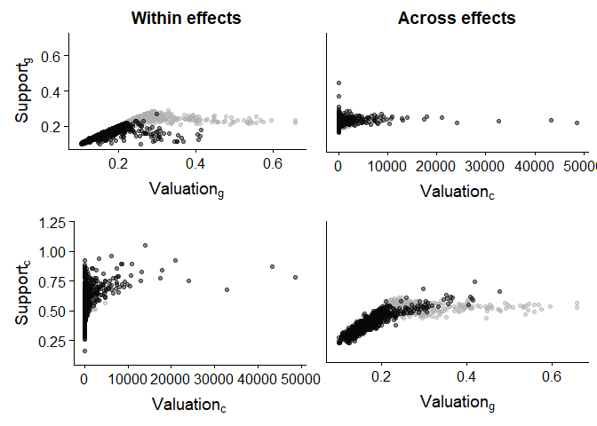

```r
f1
```

```r
  png("output/FigA1_Rain.png")
  f1
  dev.off()
```

## Table 6. The Impact of Complementarity: Within and Across Effects (Rain)

```r
# Confidence Intervals Rain
low <- rain_med_DF[rain_med_DF$level == "low", c("v_c", "v_g", "sG_given_vg", "sG_given_vc", "sC_given_vc", "sC_given_vg" )]

high <- rain_med_DF[rain_med_DF$level == "high",c("v_c", "v_g", "sG_given_vg", "sG_given_vc", "sC_given_vc", "sC_given_vg" ) ]

# low
apply(low, 2, quantile, probs = c(0.025, 0.5, 0.975))
```

```
##               v_c       v_g sG_given_vg sG_given_vc sC_given_vc
## 2.5%     1.042357 0.2145054   0.2096376   0.2102068   0.4569728
## 50%     59.116714 0.2468122   0.2385931   0.2376566   0.5137502
## 97.5% 1204.983267 0.4493158   0.2707590   0.2696756   0.5643755
##       sC_given_vg
## 2.5%    0.4552045
## 50%     0.5149792
## 97.5%   0.5656201
```

```r
# high
apply(high, 2, quantile, probs = c(0.025, 0.5, 0.975))
```

```
##                v_c       v_g sG_given_vg sG_given_vc sC_given_vc
## 2.5%     0.7539725 0.1142419   0.1089424   0.2033997   0.3434441
## 50%     77.2719605 0.1619342   0.1563478   0.2382617   0.5337331
## 97.5% 7348.8590792 0.2947581   0.2041866   0.2796816   0.8159559
##       sC_given_vg
## 2.5%    0.2497117
## 50%     0.3645722
## 97.5%   0.5288197
```

```r
ACME <-   high - low

# Difference in mean CI
kable(apply(ACME, 2, quantile, probs = c(0.025, 0.5, 0.975)), digits = 4)
```

|  | v_c | v_g | sG_given_vg | sG_given_vc | sC_given_vc | sC_given_vg |
| --- | --- | --- | --- | --- | --- | --- |
| 2.5% | -788.3894 | -0.1881 | -0.1460 | -0.0180 | -0.1878 | -0.2565 |
| 50% | 2.7755 | -0.0892 | -0.0833 | 0.0005 | 0.0190 | -0.1462 |
| 97.5% | 7164.1305 | -0.0174 | -0.0173 | 0.0202 | 0.3288 | 0.0078 |

# Figure A2: Mediation Effects of Valuations on Support for the Conflict Shock

```r
png(filename = "mediation2.png")

direct_conflict_sg <- ggplot(data = confl_med_DF , aes(x = v_g, y =  sG_given_vg )) +
  xlab(expression('Valuation'[g])) +
  ylab(expression('Support'[g])) +
  ggtitle("Within effects" , subtitle = NULL) +
  geom_point(aes(color = level),  alpha = 0.5) +
  scale_color_manual(values = c("grey3", "grey69"))+
  theme(legend.position="none")

indirect_conflict_sg <- ggplot(data = confl_med_DF , aes(x = v_c, y =  sG_given_vc )) +
 xlab(expression('Valuation'[c]))  +
 theme(axis.title.y=element_blank(),
 axis.text.y=element_blank(),
 axis.ticks.y=element_blank()) +
 ggtitle("Across effects", subtitle = NULL) +
 geom_point(aes(color = level),  alpha = 0.5)+
 scale_color_manual(values = c("grey3", "grey69"))   +
 theme(legend.position="none")

direct_conflict_sc <- ggplot(data = confl_med_DF , aes(x = v_c, y =  sC_given_vc )) +
  xlab(expression('Valuation'[c])) +
  ylab((expression('Support'[c])) ) +
  geom_point(aes(color = level),  alpha = 0.5) +
  scale_color_manual(values = c("grey3", "grey69"))+
  theme(legend.position="none")

indirect_conflict_sc <- ggplot(data = confl_med_DF , aes(x = v_g, y =  sC_given_vg )) +
  xlab((expression('Valuation'[g])) )  +
  theme(axis.title.y=element_blank(),
  axis.text.y=element_blank(),
  axis.ticks.y=element_blank()) +
  ylim(0.2, 0.8) +
  geom_point(aes(color = level),  alpha = 0.5)+
  scale_color_manual(values = c("grey3", "grey69"))   +
  theme(legend.position="none")

# Change the line type
f2 <- cowplot::plot_grid(direct_conflict_sg, indirect_conflict_sg, direct_conflict_sc, indirect_conflict_sc ,rel_widths=c(1,0.9) )

f2
dev.off()
```

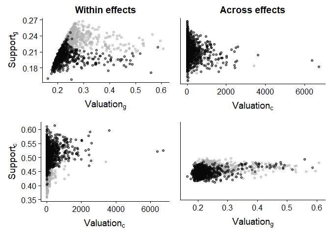

```r
f2
```

```r
  png("output/FigA2_Conflict.png")
  f2
  dev.off()
```

## Table A15. The Impact of Complementarity: Within and Across Effects (Conflict)

```r
# Confidence Intervals Conflict

l <- confl_med_DF[confl_med_DF$level=="low",  c("v_c", "v_g", "sG_given_vg", "sG_given_vc", "sC_given_vc", "sC_given_vg" )]
h <- confl_med_DF[confl_med_DF$level=="high", c("v_c", "v_g", "sG_given_vg", "sG_given_vc", "sC_given_vc", "sC_given_vg")]

# High
round(apply(h, 2, quantile, probs = c(0.025, 0.5, 0.975)), 4)
```

```
##             v_c    v_g sG_given_vg sG_given_vc sC_given_vc sC_given_vg
## 2.5%     0.9820 0.1863      0.1790      0.2015      0.4480      0.3452
## 50%     77.2742 0.2106      0.2015      0.2323      0.5118      0.4008
## 97.5% 1600.1261 0.3796      0.2224      0.2642      0.5739      0.4695
```

```r
# Low
round(apply(l, 2, quantile, probs = c(0.025, 0.5, 0.975)), 4)
```

```
##            v_c    v_g sG_given_vg sG_given_vc sC_given_vc sC_given_vg
## 2.5%    0.9013 0.2052      0.2002      0.1998      0.3905      0.3900
## 50%    28.5535 0.2394      0.2287      0.2284      0.4429      0.4438
## 97.5% 500.9617 0.4292      0.2557      0.2560      0.4959      0.4965
```

```r
kable((apply(h - l, 2, quantile, probs = c(0.025, 0.5, 0.975))), digits = 4)
```

|  | v_c | v_g | sG_given_vg | sG_given_vc | sC_given_vc | sC_given_vg |
| --- | --- | --- | --- | --- | --- | --- |
| 2.5% | 0.0228 | -0.0717 | -0.0507 | -0.0062 | 0.0064 | -0.0802 |
| 50% | 43.6402 | -0.0299 | -0.0272 | 0.0033 | 0.0699 | -0.0430 |
| 97.5% | 1040.8681 | -0.0079 | -0.0051 | 0.0176 | 0.1274 | 0.0043 |

# Table A1. Additional Summary Information

```r
# Chief activities

chief_activities <-  c("cq057_a_managed_conflict",
                       "cq058_a_conflict_same_locality",
                       "cq059_a_conflict_different_local",
                       "cq060_a_stealing",
                       "cq061_a_legal_problems",
                       "cq062_a_between_villagers",
                       "cq063_a_social",
                       "cq073_a_marriage",
                       "cq074_a_other_activities")

gvars <- data.frame(family  = c("Chief Activities", rep("",length(chief_activities)-1)),
                    dep_var = c("Manage local conflict",
                                "Manage conflict between villages",
                                "Manage external conflict",
                                "Managed stealing problems",
                                "Managed marriage problems",
                                "Managed local violence",
                                "Managed social violence",
                                "Conduct wedding/ baptism/ etc",
                                "Other" ))

 gsumm_vill <- cbind(gvars, t(sapply(chief_activities, summ, my_data = hh )))

# Individual Characteristics


 gvars <- data.frame(family  = c("Individual characteristics", rep("",2)),
                    dep_var = c("Age (x10)",
                                "Literacy",
                                "Male" ))

 gsumm_ind <- cbind(gvars, t(sapply(c("age", "lit", "male"), summ )))

kable( rbind(gsumm_vill, gsumm_ind ),
       row.names = FALSE,
       col.names = c("Level", "Description", "Obs", "Mean", "St. Dev", "Min", "Max"),
       digits = 3)
```

| Level | Description | Obs | Mean | St. Dev | Min | Max |
| --- | --- | --- | --- | --- | --- | --- |
| Chief Activities | Manage local conflict | 3535 | 0.440 | 0.496 | 0.0 | 1.0 |
|  | Manage conflict between villages | 3550 | 0.218 | 0.413 | 0.0 | 1.0 |
|  | Manage external conflict | 3545 | 0.157 | 0.363 | 0.0 | 1.0 |
|  | Managed stealing problems | 3580 | 0.458 | 0.498 | 0.0 | 1.0 |
|  | Managed marriage problems | 3575 | 0.540 | 0.498 | 0.0 | 1.0 |
|  | Managed local violence | 3535 | 0.400 | 0.490 | 0.0 | 1.0 |
|  | Managed social violence | 3575 | 0.575 | 0.494 | 0.0 | 1.0 |
|  | Conduct wedding/ baptism/ etc | 3500 | 0.076 | 0.265 | 0.0 | 1.0 |
|  | Other | 3480 | 0.353 | 0.478 | 0.0 | 1.0 |
| Individual characteristics | Age (x10) | 3639 | 4.118 | 1.462 | 1.8 | 10.4 |
|  | Literacy | 3713 | 0.575 | 0.494 | 0.0 | 1.0 |
|  | Male | 3713 | 0.512 | 0.500 | 0.0 | 1.0 |

# Appendix C. Attrition and Missing Responses

We presents the number of targeted and actually visited villages. We consider a village as visited if at least one household survey was collected in that village or a chief survey.

```r
# Number of villages visited
# Use the variable answered for all households where data was collected (q11)
# Same for chief survey (cq7)

q11 <- aggregate(q011_sex ~ IDV, data = hh, function(x) {sum(!is.na(x))}, na.action = NULL)
colnames(q11) <- c("IDV","q11")
vill_data <- merge(vill_data, q11, by="IDV", all=TRUE)
vill_data$StepD  <- (!(vill_data$cq007_date=="") | vill_data$q11>0)
villages_visited <- length(vill_data$StepD[vill_data$StepD==1])

vill_data$Province[vill_data$IDV < 50000] <-"SK"
vill_data$Province[vill_data$IDV < 40000] <-"TG"
vill_data$Province[vill_data$IDV < 30000] <-"MN"
vill_data$Province[vill_data$IDV < 20000] <-"HK"

villages_visited
```

```
## [1] 815
```

```r
table(vill_data$StepD, vill_data$Province)
```

```
##
##          HK  MN  SK  TG
##   FALSE  10 259  11  25
##   TRUE  286  35 287 207
```

Number of households for which we collected data.

```r
# Number of households visited

length(hh$q011_sex[!is.na(hh$q011_sex) & hh$IDS_TYPES=="DML"])
```

```
## [1] 0
```

Next, we regress village attrition on our rainfall and conflict shock variables.

```r
# Create missing village variable
vill_data$vill_notvisited <- 1-vill_data$StepD
table(vill_data$vill_notvisited, vill_data$StepD)
```

```
##
##     FALSE TRUE
##   0     0  815
##   1   305    0
```

Results for rainfall shock:

```r
res_rain <- estimatr::lm_robust(vill_notvisited ~ avg_rain_dev + as.factor(IDS_CHEF), data = vill_data)
summary(res_rain)$coefficients[2,1:3]
```

```
##    Estimate  Std. Error     t value
## 0.005847093 0.008327279 0.702161257
```

Result for conflict shock:

```r
res_conflict <- estimatr::lm_robust(vill_notvisited ~ Confl_Shock + as.factor(IDS_CHEF), data = vill_data )
summary(res_conflict)$coefficients[2,1:3]
```

```
##    Estimate  Std. Error     t value
## 0.011180280 0.006316709 1.769953447
```

This concludes the replication file.